# TeslaStockPrice

## Importing Libararies

```python
!pip install xgboost
```

```python
import pandas as pd
import numpy as np
import matplotlib.pyplot as plt
import seaborn as sb

from sklearn.model_selection import train_test_split
from sklearn.preprocessing import StandardScaler
from sklearn.linear_model import LogisticRegression
from sklearn.svm import SVC
from xgboost import XGBClassifier
from sklearn import metrics

import warnings
warnings.filterwarnings('ignore')
```

## Importing DataSet

```python
df=pd.read_csv('TSLA.csv')
df
```

|  | Date | Open | High | Low | Close | Adj Close | Volume |
| --- | --- | --- | --- | --- | --- | --- | --- |
| 0 | 6/29/2010 | 3.800000 | 5.000000 | 3.508000 | 4.778000 | 4.778000 | 93831500 |
| 1 | 6/30/2010 | 5.158000 | 6.084000 | 4.660000 | 4.766000 | 4.766000 | 85935500 |
| 2 | 7/1/2010 | 5.000000 | 5.184000 | 4.054000 | 4.392000 | 4.392000 | 41094000 |
| 3 | 7/2/2010 | 4.600000 | 4.620000 | 3.742000 | 3.840000 | 3.840000 | 25699000 |
| 4 | 7/6/2010 | 4.000000 | 4.000000 | 3.166000 | 3.222000 | 3.222000 | 34334500 |
| ... | ... | ... | ... | ... | ... | ... | ... |
| 2951 | 3/18/2022 | 874.489990 | 907.849976 | 867.390015 | 905.390015 | 905.390015 | 33408500 |
| 2952 | 3/21/2022 | 914.979980 | 942.849976 | 907.090027 | 921.159973 | 921.159973 | 27327200 |
| 2953 | 3/22/2022 | 930.000000 | 997.859985 | 921.750000 | 993.979980 | 993.979980 | 35289500 |
| 2954 | 3/23/2022 | 979.940002 | 1040.699951 | 976.400024 | 999.109985 | 999.109985 | 40225400 |
| 2955 | 3/24/2022 | 1009.729980 | 1024.489990 | 988.799988 | 1013.919983 | 1013.919983 | 22901900 |

2956 rows × 7 columns

```python
df.shape
```

```
(2956, 7)
```

```python
df.describe()
```

|  | Open | High | Low | Close | Adj Close | Volume |
| --- | --- | --- | --- | --- | --- | --- |
| count | 2956.000000 | 2956.000000 | 2956.000000 | 2956.000000 | 2956.000000 | 2.956000e+03 |
| mean | 138.691296 | 141.771603 | 135.425953 | 138.762183 | 138.762183 | 3.131449e+07 |
| std | 250.044839 | 255.863239 | 243.774157 | 250.123115 | 250.123115 | 2.798383e+07 |
| min | 3.228000 | 3.326000 | 2.996000 | 3.160000 | 3.160000 | 5.925000e+05 |
| 25% | 19.627000 | 20.402000 | 19.127500 | 19.615000 | 19.615000 | 1.310288e+07 |
| 50% | 46.656999 | 47.487001 | 45.820002 | 46.545000 | 46.545000 | 2.488680e+07 |
| 75% | 68.057001 | 69.357500 | 66.911501 | 68.103998 | 68.103998 | 3.973875e+07 |
| max | 1234.410034 | 1243.489990 | 1217.000000 | 1229.910034 | 1229.910034 | 3.046940e+08 |

```python
df.info()
```

```
<class 'pandas.core.frame.DataFrame'>
RangeIndex: 2956 entries, 0 to 2955
Data columns (total 7 columns):
 #   Column     Non-Null Count  Dtype
---  ------     --------------  -----
 0   Date       2956 non-null   object
 1   Open       2956 non-null   float64
 2   High       2956 non-null   float64
 3   Low        2956 non-null   float64
 4   Close      2956 non-null   float64
 5   Adj Close  2956 non-null   float64
 6   Volume     2956 non-null   int64
dtypes: float64(5), int64(1), object(1)
memory usage: 161.8+ KB
```

### Exploratory Data Analysis

While performing the EDA of the Tesla Stock Price data we will analyze how prices of the stock have moved over the period of time and how the end of the quarters affects the prices of the stock.

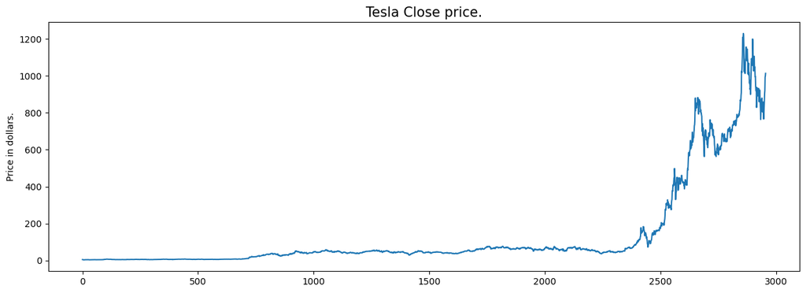

```python
plt.figure(figsize=(15,5))
plt.plot(df['Close'])
plt.title('Tesla Close price.', fontsize=15)
plt.ylabel('Price in dollars.')
plt.show()
```

The prices of tesla stocks are showing an upward trend as depicted by the plot of the closing price of the stocks.

#### Checking if 'Close' and 'Adj Close' col are same and dropping the redundant col

```python
df.head()
```

|  | Date | Open | High | Low | Close | Adj Close | Volume |
| --- | --- | --- | --- | --- | --- | --- | --- |
| 0 | 6/29/2010 | 3.800 | 5.000 | 3.508 | 4.778 | 4.778 | 93831500 |
| 1 | 6/30/2010 | 5.158 | 6.084 | 4.660 | 4.766 | 4.766 | 85935500 |
| 2 | 7/1/2010 | 5.000 | 5.184 | 4.054 | 4.392 | 4.392 | 41094000 |
| 3 | 7/2/2010 | 4.600 | 4.620 | 3.742 | 3.840 | 3.840 | 25699000 |
| 4 | 7/6/2010 | 4.000 | 4.000 | 3.166 | 3.222 | 3.222 | 34334500 |

```python
df[df['Close'] == df['Adj Close']].shape ## checking
```

```
(2956, 7)
```

```python
df=df.drop(['Adj Close'],axis=1) ## dropping 'Adj Close'
```

```python
df.head()
```

|  | Date | Open | High | Low | Close | Volume |
| --- | --- | --- | --- | --- | --- | --- |
| 0 | 6/29/2010 | 3.800 | 5.000 | 3.508 | 4.778 | 93831500 |
| 1 | 6/30/2010 | 5.158 | 6.084 | 4.660 | 4.766 | 85935500 |
| 2 | 7/1/2010 | 5.000 | 5.184 | 4.054 | 4.392 | 41094000 |
| 3 | 7/2/2010 | 4.600 | 4.620 | 3.742 | 3.840 | 25699000 |
| 4 | 7/6/2010 | 4.000 | 4.000 | 3.166 | 3.222 | 34334500 |

#### Checking for null values

```python
df.isnull().sum()
```

```
Date      0
Open      0
High      0
Low       0
Close     0
Volume    0
dtype: int64
```

#### Distribution plot for the continuous features

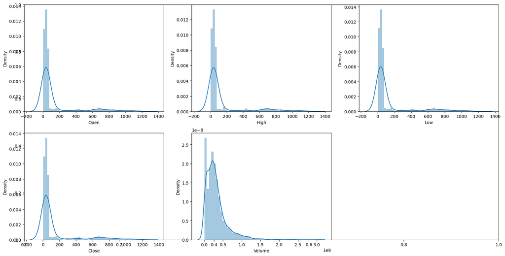

```python
features = ['Open', 'High', 'Low', 'Close', 'Volume']

plt.subplots(figsize=(20,10))

for i, col in enumerate(features):
  plt.subplot(2,3,i+1)
  sb.distplot(df[col])
plt.show()
```

```python
In the distribution plot of OHLC data, we can see most values concentrate near lower price ranges and are long tailed towards the right side.
Peak on left and long tail on right which is quite common in stock market data.
```

```python
## Outliers
```

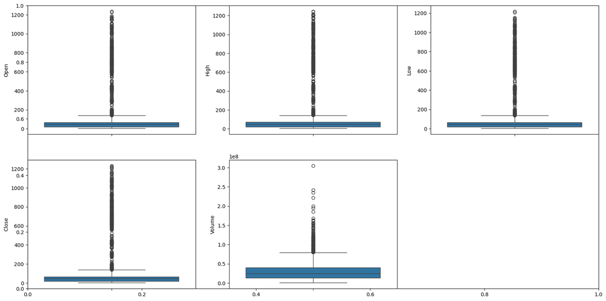

```python
plt.subplots(figsize=(20,10))
for i, col in enumerate(features):
  plt.subplot(2,3,i+1)
  sb.boxplot(df[col])
plt.show()
```

Small Box Near Bottom - most stock prices are concentrated in lower ranges Long Upper Tail - some very high stock prices exist indicating Positive (Right) Skewness Many Outliers exsists - black circles above whiskers indicate: extreme stock price values because of Tesla rapid growth periods, stock split,market rallies,volatility spikes